# Pima Indians Diabete

Mehedi Hasan Mir

2025-01-29

# Packages

Loading required packages:

```r
library(dplyr)
library(knitr)
library(DescTools)
library(ggplot2)
library(naniar)
library(tidyr)
```

# Importing the Pima Indians Diabetes Data

```r
df = read.csv("Data/Kaggle - Pima Indians Diabetes Database.csv")
head(df)
```

```
##   Pregnancies Glucose BloodPressure SkinThickness Insulin  BMI
## 1           6     148            72            35       0 33.6
## 2           1      85            66            29       0 26.6
## 3           8     183            64             0       0 23.3
## 4           1      89            66            23      94 28.1
## 5           0     137            40            35     168 43.1
## 6           5     116            74             0       0 25.6
##   DiabetesPedigreeFunction Age Outcome
## 1                    0.627  50       1
## 2                    0.351  31       0
## 3                    0.672  32       1
## 4                    0.167  21       0
## 5                    2.288  33       1
## 6                    0.201  30       0
```

Here is what the columns in the data mean:

| Column | Details |
| --- | --- |
| Pregnancies | Number of times pregnant |
| Glucose | Plasma glucose concentration a 2 hours in an oral glucose tolerance test |
| BloodPressure | Diastolic blood pressure (mm Hg) |
| SkinThickness | Triceps skin fold thickness (mm) |
| Insulin | 2-Hour serum insulin (mu U/ml) |
| BMI | Body mass index (weight in kg/(height in m)^2) |
| DiabetesPedigreeFunction | Diabetes pedigree function |
| Age | Age (years) |
| Outcome | Class variable (0=No or 1=Yes) |

**`Outcome` is a categorical variable, 1 means Yes, 0 means No. So, convert it into a factor data type. Then, calculating mean, standard deviation, minimum, 1st quartile, median, 3rd quartile, maximum, and inter-quartile range of all the numeric columns in the dataset. Here, In coloumn of Glucose, BloodPressure, SkinThickness & BMI, There are lots of 0 that is meaningless. In real life O in not exist in these columns.

```r
df$Outcome = as.factor(df$Outcome)
class(df$Outcome)
```

```
## [1] "factor"
```

```r
calculating = function(colum){
  colum = as.numeric(colum)
  mean_value = mean(colum)
  median_value = median(colum)
  mode_value = Mode(colum)
  min_value = min(colum)
  standard_value = sd(colum)
  max_value = max(colum)
  quantile = quantile(colum)
  first_quantile = quantile(colum, 0.25)
  third_quantile = quantile(colum, 0.75)
  iqr_range = IQR(colum)

  return(list(
    mean = mean_value,
    median = median_value,
    mode= mode_value,
    min = min_value,
    max = max_value,
    standard_deviation = standard_value,
    quantile_ = quantile,
    firstQuantile = first_quantile,
    thirdQuantile = third_quantile,
    iqrRange = iqr_range
  ))
}
calculating(df$Pregnancies)
```

```
## $mean
## [1] 3.845052
##
## $median
## [1] 3
##
## $mode
## [1] 1
## attr(,"freq")
## [1] 135
##
## $min
## [1] 0
##
## $max
## [1] 17
##
## $standard_deviation
## [1] 3.369578
##
## $quantile_
##   0%  25%  50%  75% 100%
##    0    1    3    6   17
##
## $firstQuantile
## 25%
##   1
##
## $thirdQuantile
## 75%
##   6
##
## $iqrRange
## [1] 5
```

```r
calculating(df$Glucose)
```

```
## $mean
## [1] 120.8945
##
## $median
## [1] 117
##
## $mode
## [1]  99 100
## attr(,"freq")
## [1] 17
##
## $min
## [1] 0
##
## $max
## [1] 199
##
## $standard_deviation
## [1] 31.97262
##
## $quantile_
##     0%    25%    50%    75%   100%
##   0.00  99.00 117.00 140.25 199.00
##
## $firstQuantile
## 25%
##  99
##
## $thirdQuantile
##    75%
## 140.25
##
## $iqrRange
## [1] 41.25
```

```r
calculating(df$BloodPressure)
```

```
## $mean
## [1] 69.10547
##
## $median
## [1] 72
##
## $mode
## [1] 70
## attr(,"freq")
## [1] 57
##
## $min
## [1] 0
##
## $max
## [1] 122
##
## $standard_deviation
## [1] 19.35581
##
## $quantile_
##   0%  25%  50%  75% 100%
##    0   62   72   80  122
##
## $firstQuantile
## 25%
##  62
##
## $thirdQuantile
## 75%
##  80
##
## $iqrRange
## [1] 18
```

```r
calculating(df$SkinThickness)
```

```
## $mean
## [1] 20.53646
##
## $median
## [1] 23
##
## $mode
## [1] 0
## attr(,"freq")
## [1] 227
##
## $min
## [1] 0
##
## $max
## [1] 99
##
## $standard_deviation
## [1] 15.95222
##
## $quantile_
##   0%  25%  50%  75% 100%
##    0    0   23   32   99
##
## $firstQuantile
## 25%
##   0
##
## $thirdQuantile
## 75%
##  32
##
## $iqrRange
## [1] 32
```

```r
calculating(df$Insulin)
```

```
## $mean
## [1] 79.79948
##
## $median
## [1] 30.5
##
## $mode
## [1] 0
## attr(,"freq")
## [1] 374
##
## $min
## [1] 0
##
## $max
## [1] 846
##
## $standard_deviation
## [1] 115.244
##
## $quantile_
##     0%    25%    50%    75%   100%
##   0.00   0.00  30.50 127.25 846.00
##
## $firstQuantile
## 25%
##   0
##
## $thirdQuantile
##    75%
## 127.25
##
## $iqrRange
## [1] 127.25
```

```r
calculating(df$BMI)
```

```
## $mean
## [1] 31.99258
##
## $median
## [1] 32
##
## $mode
## [1] 32
## attr(,"freq")
## [1] 13
##
## $min
## [1] 0
##
## $max
## [1] 67.1
##
## $standard_deviation
## [1] 7.88416
##
## $quantile_
##   0%  25%  50%  75% 100%
##  0.0 27.3 32.0 36.6 67.1
##
## $firstQuantile
##  25%
## 27.3
##
## $thirdQuantile
##  75%
## 36.6
##
## $iqrRange
## [1] 9.3
```

```r
calculating(df$DiabetesPedigreeFunction)
```

```
## $mean
## [1] 0.4718763
##
## $median
## [1] 0.3725
##
## $mode
## [1] 0.254 0.258
## attr(,"freq")
## [1] 6
##
## $min
## [1] 0.078
##
## $max
## [1] 2.42
##
## $standard_deviation
## [1] 0.3313286
##
## $quantile_
##      0%     25%     50%     75%    100%
## 0.07800 0.24375 0.37250 0.62625 2.42000
##
## $firstQuantile
##     25%
## 0.24375
##
## $thirdQuantile
##     75%
## 0.62625
##
## $iqrRange
## [1] 0.3825
```

```r
calculating(df$Age)
```

```
## $mean
## [1] 33.24089
##
## $median
## [1] 29
##
## $mode
## [1] 22
## attr(,"freq")
## [1] 72
##
## $min
## [1] 21
##
## $max
## [1] 81
##
## $standard_deviation
## [1] 11.76023
##
## $quantile_
##   0%  25%  50%  75% 100%
##   21   24   29   41   81
##
## $firstQuantile
## 25%
##  24
##
## $thirdQuantile
## 75%
##  41
##
## $iqrRange
## [1] 17
```

```r
calculating(df$Outcome)
```

```
## $mean
## [1] 1.348958
##
## $median
## [1] 1
##
## $mode
## [1] 1
## attr(,"freq")
## [1] 500
##
## $min
## [1] 1
##
## $max
## [1] 2
##
## $standard_deviation
## [1] 0.4769514
##
## $quantile_
##   0%  25%  50%  75% 100%
##    1    1    1    2    2
##
## $firstQuantile
## 25%
##   1
##
## $thirdQuantile
## 75%
##   2
##
## $iqrRange
## [1] 1
```

**Let’s see how many people have Outcome = Yes?**

```r
yes_outcone = df %>%
  filter(Outcome == 1)
count(yes_outcone)
```

```
##     n
## 1 268
```

**Creating histograms for all the numeric variables in the data using ggplot2.**

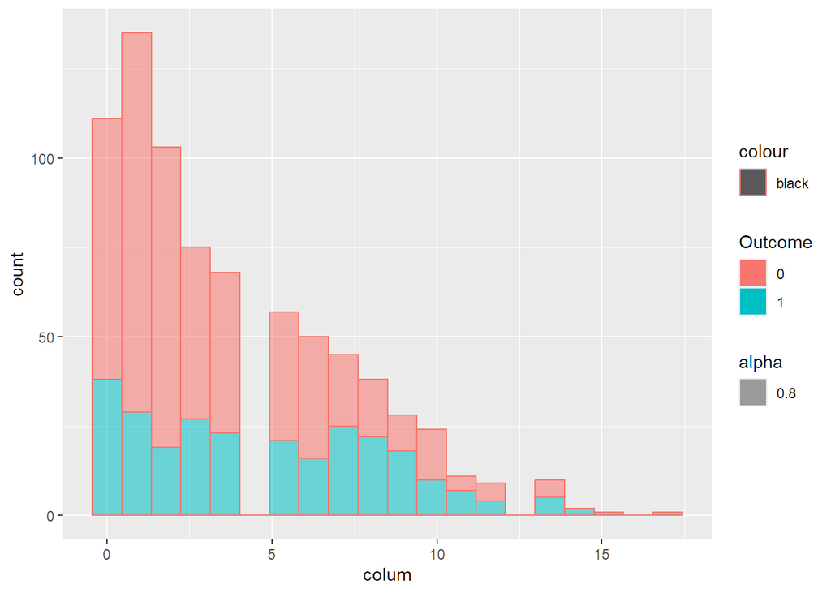

```r
histplot = function(colum){
  colum = as.numeric(colum)
  ggplot(data = df) +
    geom_histogram(aes(x = colum, fill = Outcome, colour = "black", alpha = 0.8),
                   bins = 20)
}
histplot(df$Pregnancies)
```

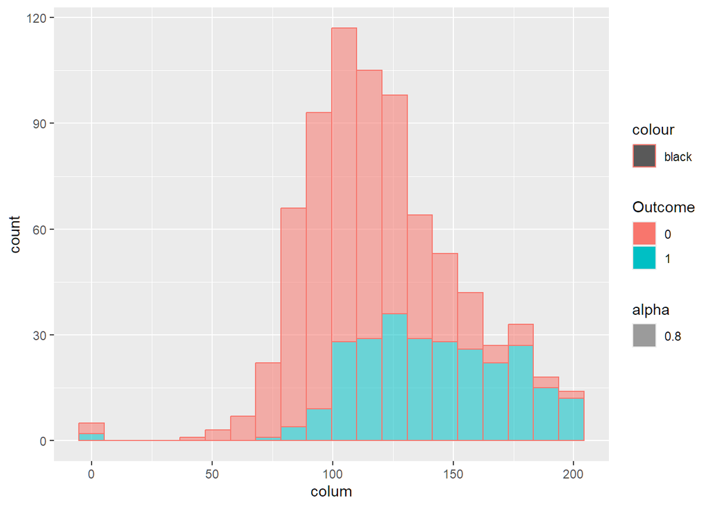

```r
histplot(df$Glucose)
```

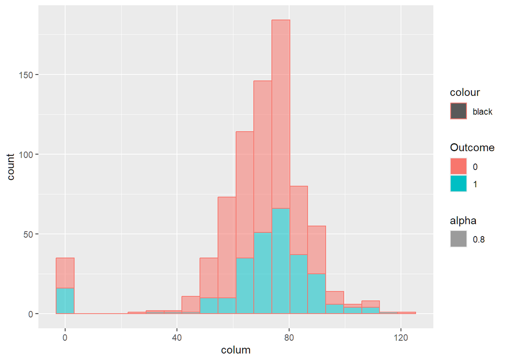

```r
histplot(df$BloodPressure)
```

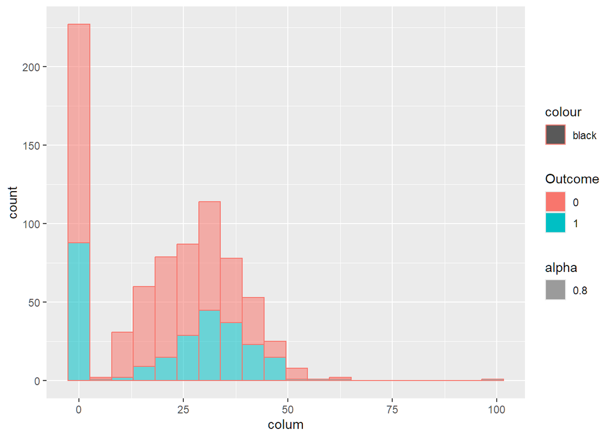

```r
histplot(df$SkinThickness)
```

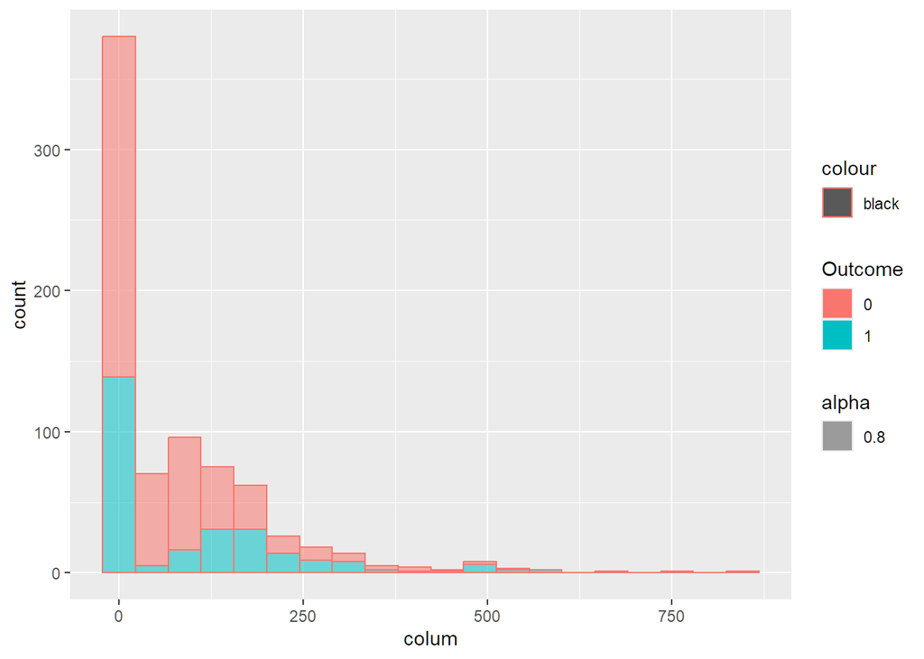

```r
histplot(df$Insulin)
```

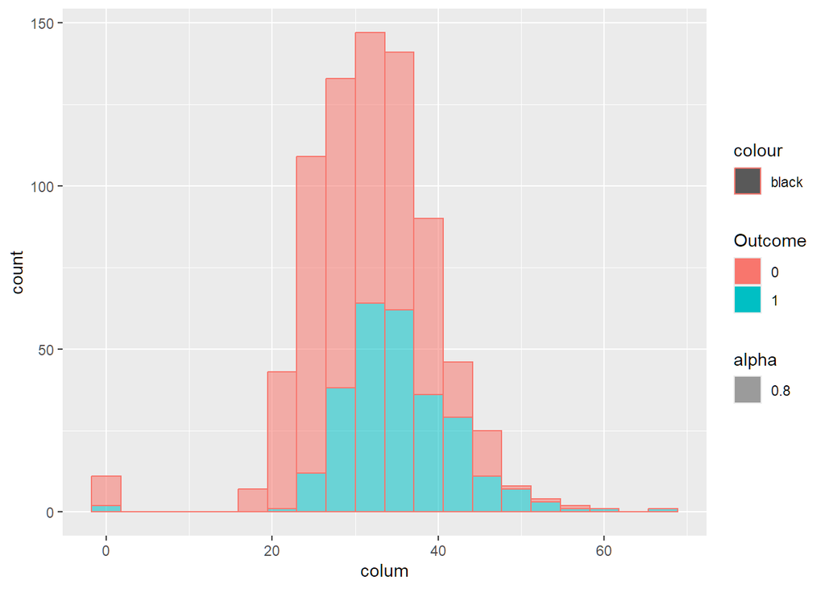

```r
histplot(df$BMI)
```

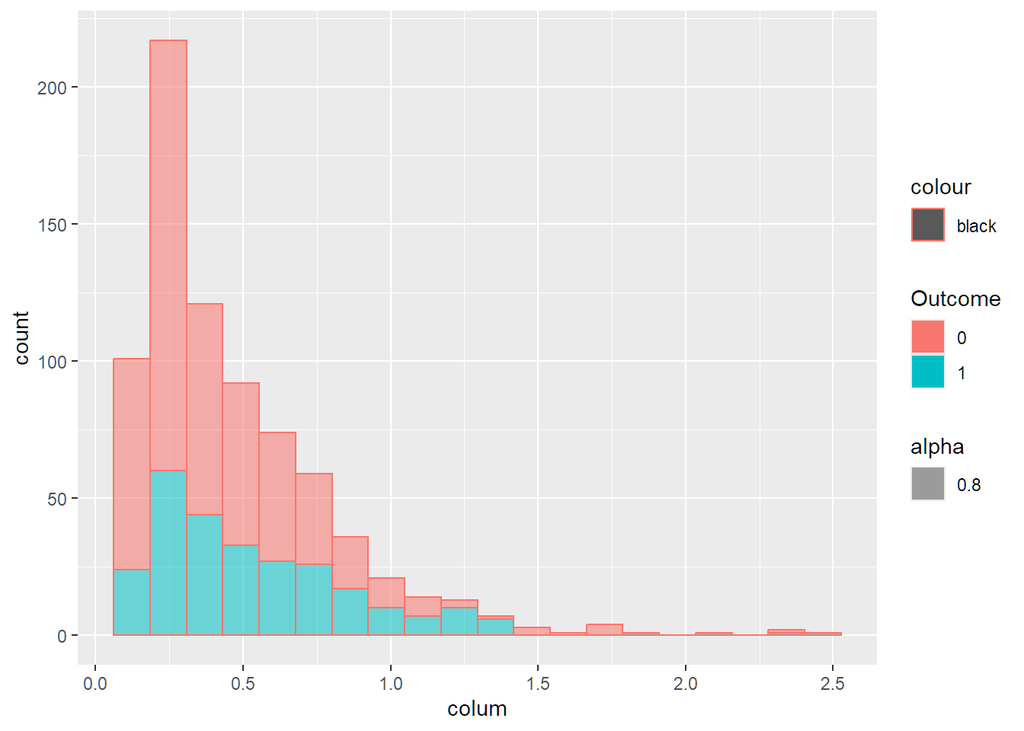

```r
histplot(df$DiabetesPedigreeFunction)
```

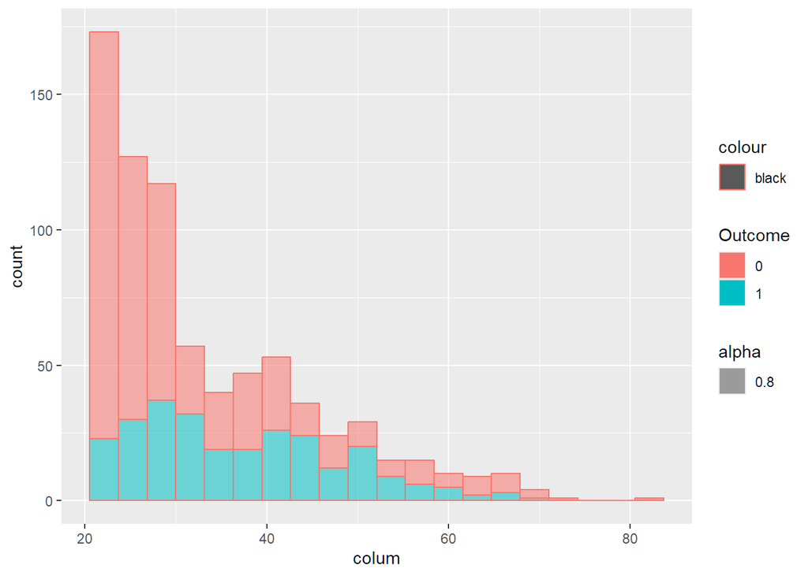

```r
histplot(df$Age)
```

**Creating boxplot of Glucose, Insulin, BMI, and Age by Outcome using ggplot2.**

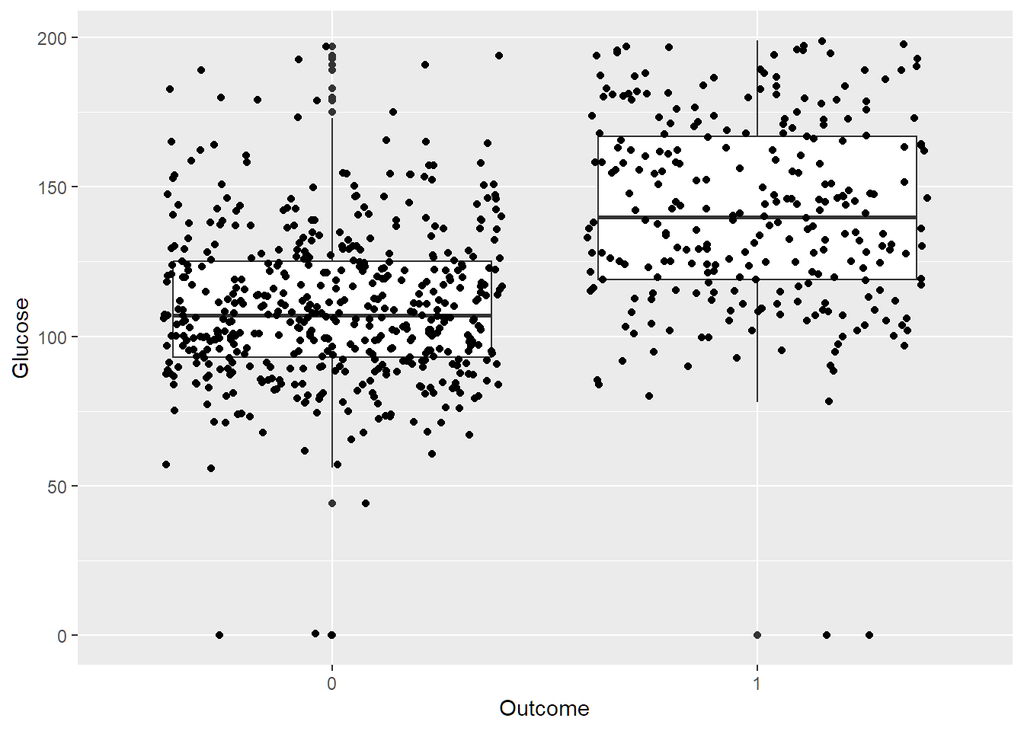

```r
df %>%
  ggplot(aes(x = Outcome, y = Glucose))+
   geom_boxplot()+
  geom_jitter()
```

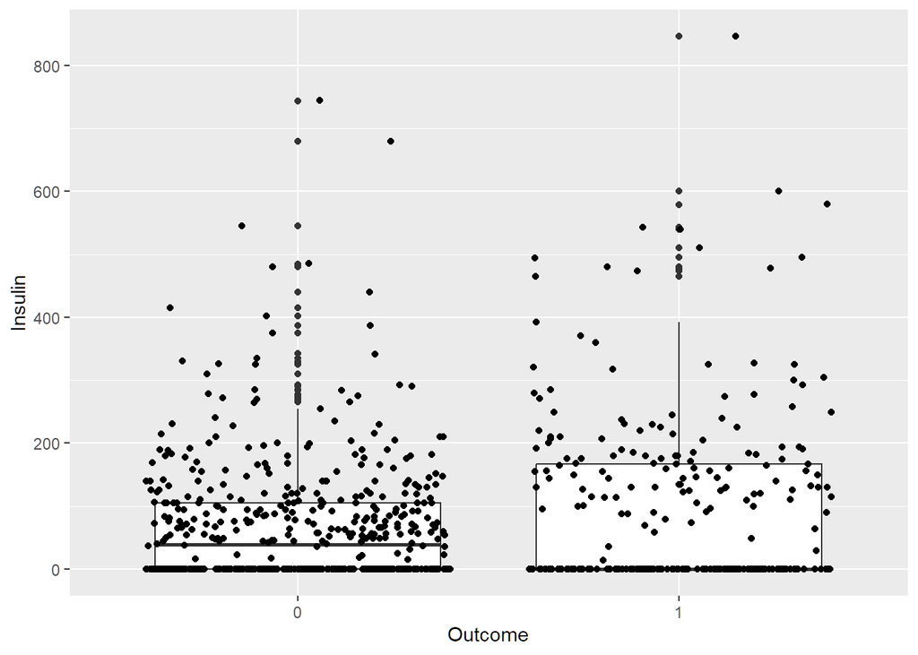

```r
df %>%
  ggplot(aes(x = Outcome, y = Insulin))+
  geom_boxplot()+
  geom_jitter()
```

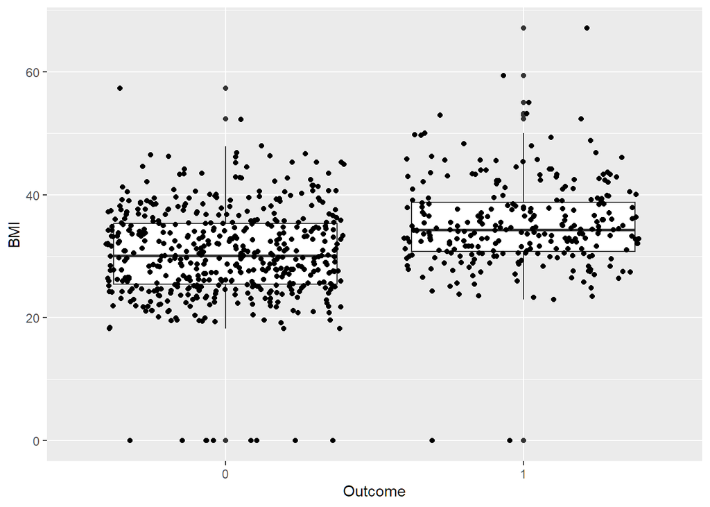

```r
df %>%
  ggplot(aes(x = Outcome, y = BMI))+
  geom_boxplot()+
  geom_jitter()
```

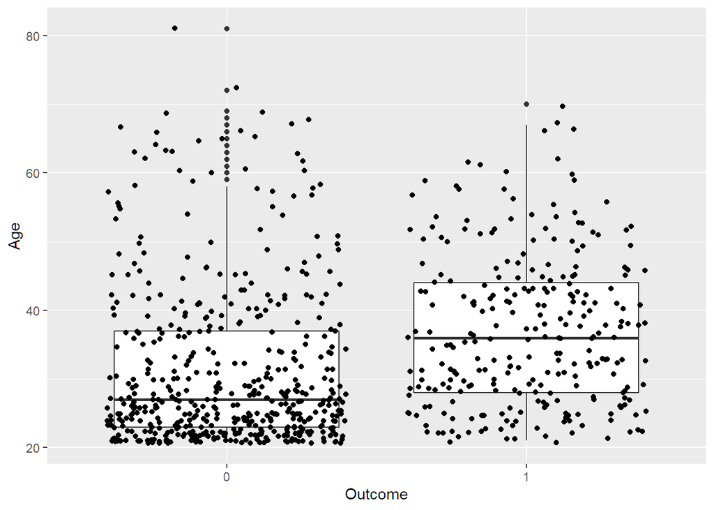

```r
df %>%
  ggplot(aes(x = Outcome, y = Age))+
  geom_boxplot()+
  geom_jitter()
```

**Replacing 0 with NA in the variables where a value of 0 does not make sense.**

```r
null_column = colSums(is.na(df))
zero_col = colSums(df==0)
df$Glucose[df$Glucose == 0] = NA
df$BloodPressure[df$BloodPressure == 0] = NA
df$SkinThickness[df$SkinThickness == 0] = NA
df$BMI[df$BMI == 0] = NA
head(df)
```

```
##   Pregnancies Glucose BloodPressure SkinThickness Insulin  BMI
## 1           6     148            72            35       0 33.6
## 2           1      85            66            29       0 26.6
## 3           8     183            64            NA       0 23.3
## 4           1      89            66            23      94 28.1
## 5           0     137            40            35     168 43.1
## 6           5     116            74            NA       0 25.6
##   DiabetesPedigreeFunction Age Outcome
## 1                    0.627  50       1
## 2                    0.351  31       0
## 3                    0.672  32       1
## 4                    0.167  21       0
## 5                    2.288  33       1
## 6                    0.201  30       0
```

**Useing naniar package to inspect number of missing values in the data after replacing 0’s with NA’s**

```r
miss_var_summary(df)
```

```
## # A tibble: 9 × 3
##   variable                 n_miss pct_miss
##   <chr>                     <int>    <num>
## 1 SkinThickness               227   29.6
## 2 BloodPressure                35    4.56
## 3 BMI                          11    1.43
## 4 Glucose                       5    0.651
## 5 Pregnancies                   0    0
## 6 Insulin                       0    0
## 7 DiabetesPedigreeFunction      0    0
## 8 Age                           0    0
## 9 Outcome                       0    0
```

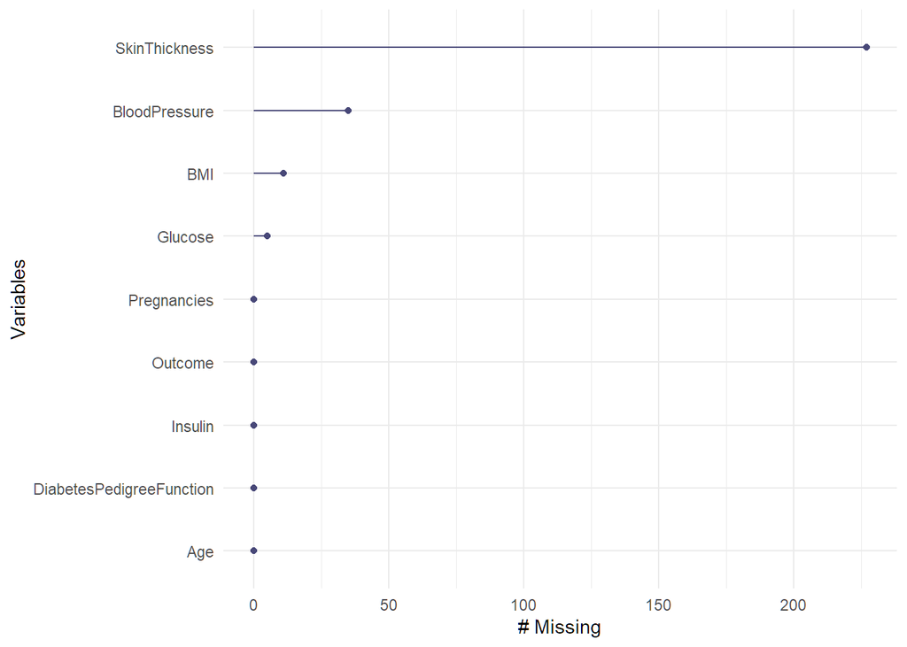

```r
gg_miss_var(df)
```

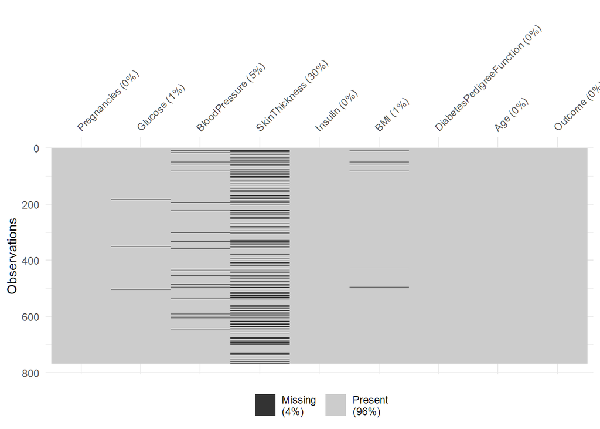

```r
vis_miss(df)
```

```r
summary(df)
```

```
##   Pregnancies        Glucose      BloodPressure    SkinThickness
##  Min.   : 0.000   Min.   : 44.0   Min.   : 24.00   Min.   : 7.00
##  1st Qu.: 1.000   1st Qu.: 99.0   1st Qu.: 64.00   1st Qu.:22.00
##  Median : 3.000   Median :117.0   Median : 72.00   Median :29.00
##  Mean   : 3.845   Mean   :121.7   Mean   : 72.41   Mean   :29.15
##  3rd Qu.: 6.000   3rd Qu.:141.0   3rd Qu.: 80.00   3rd Qu.:36.00
##  Max.   :17.000   Max.   :199.0   Max.   :122.00   Max.   :99.00
##                   NA's   :5       NA's   :35       NA's   :227
##     Insulin           BMI        DiabetesPedigreeFunction      Age
##  Min.   :  0.0   Min.   :18.20   Min.   :0.0780           Min.   :21.00
##  1st Qu.:  0.0   1st Qu.:27.50   1st Qu.:0.2437           1st Qu.:24.00
##  Median : 30.5   Median :32.30   Median :0.3725           Median :29.00
##  Mean   : 79.8   Mean   :32.46   Mean   :0.4719           Mean   :33.24
##  3rd Qu.:127.2   3rd Qu.:36.60   3rd Qu.:0.6262           3rd Qu.:41.00
##  Max.   :846.0   Max.   :67.10   Max.   :2.4200           Max.   :81.00
##                  NA's   :11
##  Outcome
##  0:500
##  1:268
##
##
##
##
##
```

```r
nrow(df)
```

```
## [1] 768
```

```r
df1 =df %>%
  mutate(SkinThickness = ifelse(is.na(SkinThickness), mean(SkinThickness, na.rm = TRUE), SkinThickness),
         BloodPressure = ifelse(is.na(BloodPressure), median(BloodPressure, na.rm = TRUE), BloodPressure))
final_df = df1 %>%
  drop_na(Glucose, BMI)
miss_var_summary(final_df)
```

```
## # A tibble: 9 × 3
##   variable                 n_miss pct_miss
##   <chr>                     <int>    <num>
## 1 Pregnancies                   0        0
## 2 Glucose                       0        0
## 3 BloodPressure                 0        0
## 4 SkinThickness                 0        0
## 5 Insulin                       0        0
## 6 BMI                           0        0
## 7 DiabetesPedigreeFunction      0        0
## 8 Age                           0        0
## 9 Outcome                       0        0
```

```r
write.csv(final_df, "Output/Processed Pima Indians Diabetes.csv", row.names = F)
```